# TargetCNV-ML: Reporte de Inferencia de CNV y Consenso Multimodelo

Votación de 7 Modelos, Sensibilidad del Umbral de Cobertura y Matriz de Copias Génicas

Author

TargetCNV-ML

Published

November 1, 2026

## 1 Resumen de la Inferencia y Consenso de 7 Modelos

Cada secuencia nuclear ensamblada por CAPTUS (`marker_type == NUC`) es clasificada por **7 métodos**: **4 modelos supervisados** (`ElasticNet`, `NaiveBayes`, `SVM_Polinomial`, `Red_Neuronal`), **2 umbrales univariados de Youden** (`pct_recovered`, `pct_identity`) y **1 ensamble heurístico ponderado**. Las secuencias que alcanzan el mínimo de votos requerido se clasifican como `Homologo_Valido` e ingresan al conteo de copias por ortogrupo.

**Fuente del Genoma de Referencia:** Reportado y publicado en el portal Solanum Pan-Genomics (https://solpangenomics.com/dist/pages/downloads/index.php), en Solanaceae Genomics Network (https://solgenomics.net/ftp/genomes/Solanum_pangenomics/) y en NCBI BioProject bajo [Accession: PRJNA1073673](https://www.ncbi.nlm.nih.gov/bioproject/PRJNA1073673).  
**Fuente de Homología y Datos Génicos:** Benoit, M. et al.: , 2025; Solanum pan-genetics reveals paralogues as contingencies in crop engineering; Nature; 640 (8057): 135–145; [doi:10.1038/s41586-025-08619-6](https://doi.org/10.1038/s41586-025-08619-6).  
**Archivos de Origen:** `consensus_verdicts.tsv, cnv_matrix.tsv, cnv_annotated_sequences.tsv`

Secuencias Evaluadas

1800

En 10 muestra(s)

Homólogos Válidos

1014 (56.3%)

Aceptados por consenso

Ruido Descartado

786 (43.7%)

Filtrados por consenso

Copias Estimadas

1014

50 ortogrupos | 584 homólogos adicionales

Fragmentos No Contados

0

Secuencias adicionales < 50.0%

**Veredicto por Muestra**

[interactive chart not shown]

**Distribución de Votos (0 a 7)**

[interactive chart not shown]

**Votos por Modelo Individual**

[interactive chart not shown]

**Tabla de Veredictos (consensus_verdicts.tsv)**

| Sample | Locus_Ortogrupo | ID_Secuencia | pct_recovered | pct_identity | score | wscore | Pred_ML_ElasticNet | Pred_ML_NaiveBayes | Pred_ML_SVM_Polinomial | Pred_ML_Red_Neuronal | Pred_Youden_pct_recovered | Pred_Youden_pct_identity | Pred_Ens_Heuristico | Votos_TP | Proporcion_Acuerdo | Veredicto_Consenso |
| --- | --- | --- | --- | --- | --- | --- | --- | --- | --- | --- | --- | --- | --- | --- | --- | --- |
| Sample_01 | OG0000001 | OG0000001__00 | 94.1 | 93.57 | 0.944 | 0.93 | TP | TP | TP | TP | TP | TP | TP | 7 | 1 | Homologo_Valido |
| Sample_01 | OG0000001 | OG0000001__01 | 73.25 | 87.9 | 0.889 | 0.871 | TP | TP | TP | TP | TP | TP | TP | 7 | 1 | Homologo_Valido |
| Sample_01 | OG0000001 | OG0000001__02 | 84.65 | 92.12 | 0.903 | 0.886 | TP | TP | TP | TP | TP | TP | TP | 7 | 1 | Homologo_Valido |
| Sample_01 | OG0000001 | OG0000001__03 | 96.78 | 91.6 | 0.915 | 0.899 | TP | TP | TP | TP | TP | TP | TP | 7 | 1 | Homologo_Valido |
| Sample_01 | OG0000001 | OG0000001__04 | 77.11 | 81.84 | 0.841 | 0.819 | TP | TP | TP | TP | TP | FP | TP | 6 | 0.857 | Homologo_Valido |
| Sample_01 | OG0000001 | OG0000001__05 | 95.97 | 94.58 | 0.972 | 0.96 | TP | TP | TP | TP | TP | TP | TP | 7 | 1 | Homologo_Valido |
| Sample_01 | OG0000001 | OG0000001__06 | 51.97 | 64.33 | 0.407 | 0.321 | FP | FP | FP | FP | FP | FP | FP | 0 | 0 | Ruido_Descartado |
| Sample_01 | OG0000001 | OG0000001__07 | 64.73 | 69.79 | 0.433 | 0.343 | FP | FP | FP | FP | FP | FP | FP | 0 | 0 | Ruido_Descartado |
| Sample_01 | OG0000002 | OG0000002__00 | 93.9 | 97.02 | 0.957 | 0.944 | TP | TP | TP | TP | TP | TP | TP | 7 | 1 | Homologo_Valido |
| Sample_01 | OG0000002 | OG0000002__01 | 83.54 | 85.8 | 0.892 | 0.874 | TP | TP | TP | TP | TP | TP | TP | 7 | 1 | Homologo_Valido |

[output cut: 1790 more lines]

## 2 Regla de Cobertura y Calibración Empírica (`30%` a `80%`)

Para controlar la sobrestimación por contigs fragmentados, las secuencias `Homologo_Valido` se ordenan por cobertura descendente (`pct_recovered`) dentro de cada muestra y ortogrupo: la primera secuencia se registra como `Copia_Principal`, los hits adicionales con `pct_recovered >= cov_threshold` se contabilizan como `Homologo_Confirmado`, y los fragmentos adicionales por debajo del umbral quedan como `No_Contado`.

**Alcance e interpretación de la regla de cobertura.** La curva de sensibilidad incluida a continuación evalúa empíricamente la estabilidad del conteo de copias entre $30\%$ y $80\%$ (con calibración frente a $\text{CNV}^{\text{real}}_{\text{OG}}$ cuando existen etiquetas espaciales o conteos de referencia). Aun con dicha calibración, dos fragmentos no solapantes de un mismo gen que superen individualmente el umbral podrían contabilizarse por separado cuando no se dispone de coordenadas de alineamiento sobre el exón o dominio específico de la sonda.

**Sensibilidad de --cov_threshold (30%–80%)**

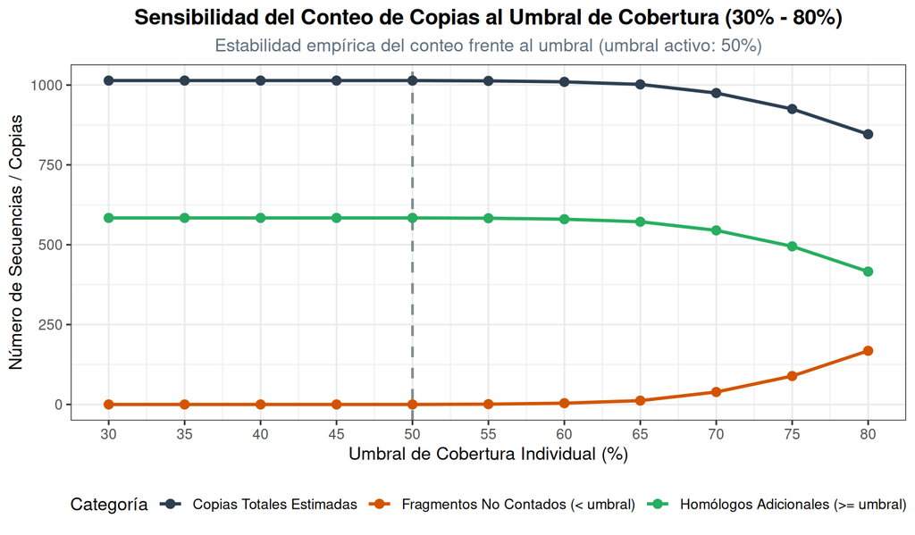

**Copias Estimadas por Muestra**

[interactive chart not shown]

**Secuencias Anotadas (cnv_annotated_sequences.tsv)**

| Sample | Locus_Ortogrupo | ID_Secuencia | pct_recovered | pct_identity | score | wscore | Votos_TP | Clasificacion_Copia |
| --- | --- | --- | --- | --- | --- | --- | --- | --- |
| Sample_01 | OG0000001 | OG0000001__03 | 96.78 | 91.6 | 0.915 | 0.899 | 7 | Copia_Principal |
| Sample_01 | OG0000001 | OG0000001__05 | 95.97 | 94.58 | 0.972 | 0.96 | 7 | Homologo_Confirmado |
| Sample_01 | OG0000001 | OG0000001__00 | 94.1 | 93.57 | 0.944 | 0.93 | 7 | Homologo_Confirmado |
| Sample_01 | OG0000001 | OG0000001__02 | 84.65 | 92.12 | 0.903 | 0.886 | 7 | Homologo_Confirmado |
| Sample_01 | OG0000001 | OG0000001__04 | 77.11 | 81.84 | 0.841 | 0.819 | 6 | Homologo_Confirmado |
| Sample_01 | OG0000001 | OG0000001__01 | 73.25 | 87.9 | 0.889 | 0.871 | 7 | Homologo_Confirmado |
| Sample_01 | OG0000002 | OG0000002__03 | 97.4 | 94.12 | 0.943 | 0.93 | 7 | Copia_Principal |
| Sample_01 | OG0000002 | OG0000002__00 | 93.9 | 97.02 | 0.957 | 0.944 | 7 | Homologo_Confirmado |
| Sample_01 | OG0000002 | OG0000002__02 | 92.84 | 97.16 | 0.961 | 0.949 | 7 | Homologo_Confirmado |
| Sample_01 | OG0000002 | OG0000002__04 | 85.73 | 91.25 | 0.883 | 0.865 | 7 | Homologo_Confirmado |

[output cut: 1004 more lines]

**Tabla de Sensibilidad y Concordancia**

| Umbral_Cobertura | Copias_Totales_Estimadas | Copias_Principales | Homologos_Confirmados | Fragmentos_No_Contados | Pares_Multicopia |
| --- | --- | --- | --- | --- | --- |
| 30 | 1014 | 430 | 584 | 0 | 238 |
| 35 | 1014 | 430 | 584 | 0 | 238 |
| 40 | 1014 | 430 | 584 | 0 | 238 |
| 45 | 1014 | 430 | 584 | 0 | 238 |
| 50 | 1014 | 430 | 584 | 0 | 238 |
| 55 | 1013 | 430 | 583 | 1 | 238 |
| 60 | 1010 | 430 | 580 | 4 | 237 |
| 65 | 1002 | 430 | 572 | 12 | 237 |
| 70 | 975 | 430 | 545 | 39 | 231 |
| 75 | 925 | 430 | 495 | 89 | 212 |

[output cut: 1 more lines]

## 3 Matriz Final de CNV y Mapa de Calor

**Mapa de Calor Interactivo (Top Ortogrupos)**

[interactive chart not shown]

**Matriz de CNV Completa (cnv_matrix.tsv)**

| Locus_Ortogrupo | Sample_01 | Sample_02 | Sample_03 | Sample_04 | Sample_05 | Sample_06 | Sample_07 | Sample_08 | Sample_09 | Sample_10 | Total_Copias | Max_Copias_Muestra |
| --- | --- | --- | --- | --- | --- | --- | --- | --- | --- | --- | --- | --- |
| OG0000005 | 8 | 7 | 9 | 8 | 7 | 8 | 6 | 8 | 8 | 7 | 76 | 9 |
| OG0000003 | 7 | 7 | 6 | 7 | 9 | 8 | 7 | 8 | 6 | 7 | 72 | 9 |
| OG0000001 | 6 | 7 | 6 | 8 | 7 | 6 | 9 | 7 | 8 | 6 | 70 | 9 |
| OG0000002 | 5 | 6 | 5 | 5 | 6 | 7 | 5 | 6 | 7 | 6 | 58 | 7 |
| OG0000004 | 4 | 5 | 6 | 4 | 5 | 6 | 5 | 6 | 4 | 5 | 50 | 6 |
| OG0000012 | 4 | 5 | 4 | 3 | 4 | 5 | 3 | 4 | 5 | 4 | 41 | 5 |
| OG0000008 | 4 | 3 | 4 | 5 | 3 | 4 | 3 | 4 | 5 | 3 | 38 | 5 |
| OG0000015 | 4 | 3 | 5 | 4 | 3 | 4 | 3 | 2 | 4 | 3 | 35 | 5 |
| OG0000006 | 3 | 4 | 3 | 2 | 4 | 3 | 5 | 4 | 3 | 2 | 33 | 5 |
| OG0000011 | 3 | 3 | 2 | 4 | 3 | 2 | 3 | 3 | 4 | 3 | 30 | 4 |

[output cut: 40 more lines]